# Capstone - Milestone Report

Omar Nooreddin

3/2/2019

# Introduction

This report aims to prepare and analyse 3 files containing: news articles, blog posts and tweets, in the hopes of a stepping stone towards building a text predictor. In this report we’ll:

- Read the files
- Prepare a data summary of these files
- Clean the data
- Build features to help in building a predictor model

By doing the above, we will get a good understanding of the data we are using to build our text predictor.

# Loading the Data

As per above, we will load three files to analyse containing news articles, blog posts and tweets.

```r
suppressPackageStartupMessages(require(tm))
suppressPackageStartupMessages(require(ngram))
suppressPackageStartupMessages(require(knitr))

#Set file paths
twitterPath<-"final/en_US/en_US.twitter.txt"
newsPath<-"final/en_US/en_US.news.txt"
blogsPath<-"final/en_US/en_US.blogs.txt"

#Read files
twitter<-readLines(twitterPath)
news<-readLines(newsPath)
blogs<-readLines(blogsPath)
```

# Basic Data Summary

In this section we will analyse aspects of the files we are dealing with. These aspects are:

- Words in each file
- Number of lines in each file
- Words per line (i.e average words per line)
- Size of each file (in megabytes)

```r
#Count number of lines in each file
twitterLines<-length(twitter)
newsLines<-length(news)
blogsLines<-length(blogs)

#Count number of words in each file
twitterWords<-sum(sapply(strsplit(twitter,split=" "),length))
newsWords<-sum(sapply(strsplit(news,split=" "),length))
blogsWords<-sum(sapply(strsplit(blogs,split=" "),length))

#Calculate size of each file
twitterSize<-file.size(twitterPath)/1024^2
newsSize<-file.size(newsPath)/1024^2
blogsSize<-file.size(blogsPath)/1024^2

#Suppress scientific notation display
options(scipen=999)

#Create table
kable(data.frame(twitter=rbind(twitterWords,twitterLines,twitterWords/twitterLines,twitterSize),
           news=rbind(newsWords,newsLines,newsWords/newsLines,newsSize),
           blogs=rbind(blogsWords,blogsLines,blogsWords/blogsLines,blogsSize),
           row.names = rbind("Words","Lines", "Words/Line","Size (mb)")),digits=0)
```

|  | twitter | news | blogs |
| --- | --- | --- | --- |
| Words | 30373543 | 34372530 | 37334131 |
| Lines | 2360148 | 1010242 | 899288 |
| Words/Line | 13 | 34 | 42 |
| Size (mb) | 159 | 196 | 200 |

We can see from the above table that number of words contained in each file is more or less the same; the number of lines is more in the twitter file, which is expected since tweets are restricted to a specific number of characters.

# Cleaning Data

In this section we are going to merge all the data together and clean it in order to perform analysis on it

### Merging and Sampling Data

First we will merge the data into one big source, after we will take a sample of the data (10% of its size) to perform analysis, this is to reduce time and load.

```r
#Combine all files together
allText<-c(twitter,news,blogs)

#Sample text file to reduce size
allText<-sample(allText, 0.1*length(allText))
```

### Cleaning Data and Preparing Data

To make our analysis much more meaningful, unnecessary data which is deemed to add no value to text prediction will be removed. We will remove:

- Punctuation
- Numbers

Also, we will convert all letters to small/lower letters in order match all instances of the same word, which is crucial in our next step. For example: “The”, “the” and “THe” will all be converted to “the”.

```r
#Convert to lower letters
allText<-tolower(allText)
#Remove punctuation
allText<-removePunctuation(allText)
#Remove numbers
allText<-removeNumbers(allText)
```

# Analysing Data (N-gram Analysis)

We will perform an “n-gram” analysis on our cleaned data set. N-gram analysis is essentially a frequency count of n-group of words. For example, “in the”, “who can” and “where the” are example of 2-gram (or bigram) groups and this section we will perform a frequency count for 1,2 and 3-gram. This will serve as a “feature” when we build our model.

```r
#Build n-grams
allText<-paste(allText, collapse = " ")

unigram<-get.phrasetable(ngram(allText, n=1))
bigram<-get.phrasetable(ngram(allText, n=2))
trigram<-get.phrasetable(ngram(allText, n=3))
```

Now that our analysis is done, we can visualise our results

### Unigram (1-gram)

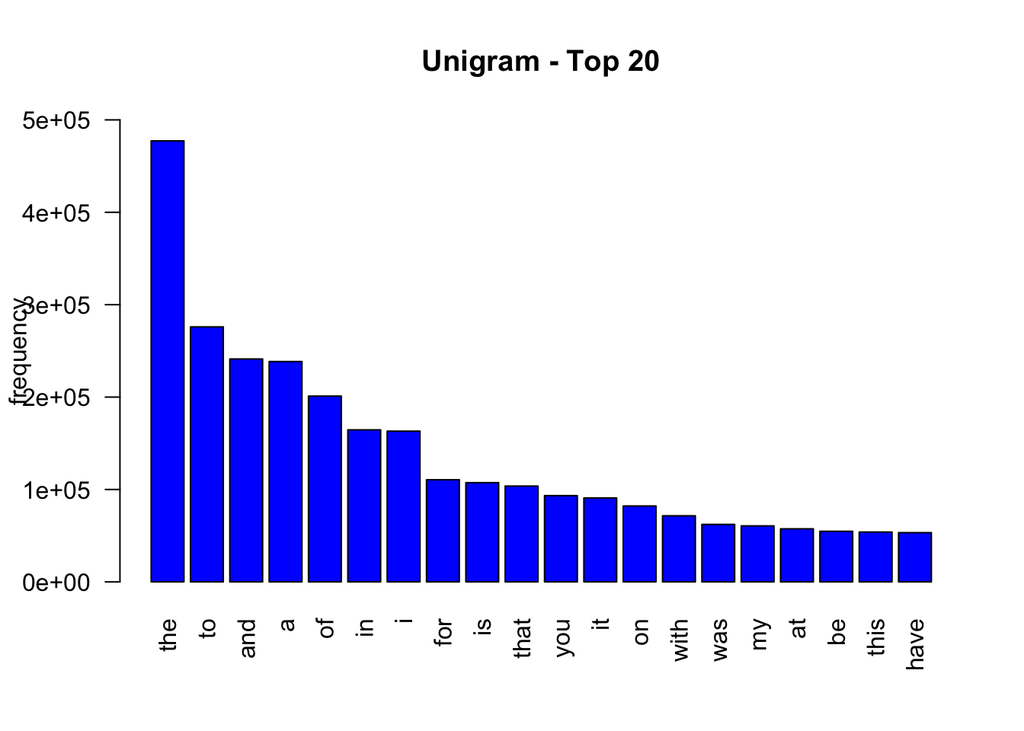

```r
#Plot n-grams
barplot(head(unigram$freq,20),names.arg = head(unigram$ngrams,20),las=2, col="blue",ylim=range(pretty(c(0, head(unigram$freq,20)))), main="Unigram - Top 20", ylab = "frequency")
```

### Bigram (2-gram)

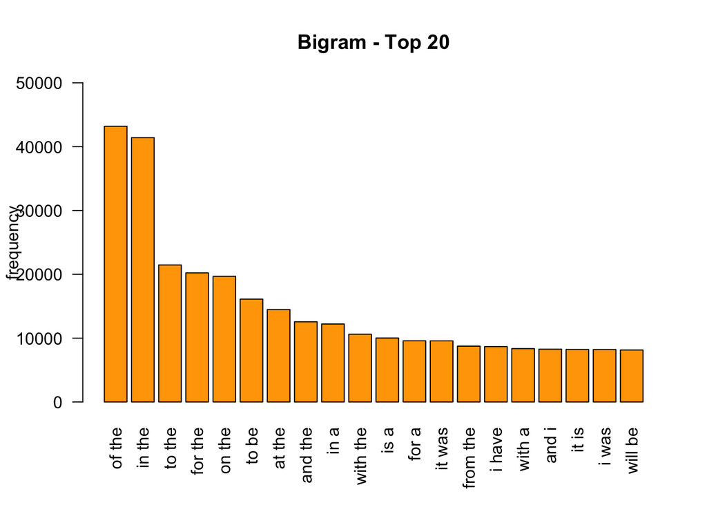

```r
barplot(head(bigram$freq,20),names.arg = head(bigram$ngrams,20),las=2, col="orange",ylim=range(pretty(c(0, head(bigram$freq,20)))), main="Bigram - Top 20", ylab = "frequency")
```

### Trigram (3-gram)

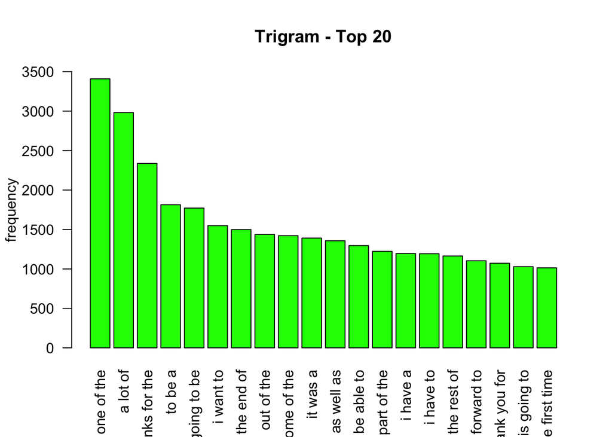

```r
barplot(head(trigram$freq,20),names.arg = head(trigram$ngrams,20),las=2, col="green",ylim=range(pretty(c(0, head(trigram$freq,20)))), main="Trigram - Top 20", ylab = "frequency")
```

# Conclusion and Observations

Following this analysis it can be noted that performing analysis on text, or text mining, is a process intensive and time consuming exercise. As a result, a sample was taken to do the analysis. So in order to build a model, which is even more process intensive, novel solutions have to be implemented.